# Stats 209 Final Project Code

Trent Bellinger

2025-11-21

https://www.datalumos.org/datalumos/project/237384/version/V1/view?path=/datalumos/237384/fcr:versions/V1/Ethiopia/Improving-Quality-of-Primary-Education-Program--IQPEP-

```r
library(tidyverse)
library(DescTools)

# read in the csv and choose the columns we will use
data <- read.csv('endline.csv', header = TRUE)
data <- data[, c("grade", "female", "age", "language", "region", "school_type",
                 "encrypted_school_code", "treatment", "read_comp_score", "orf")]

# change the treatment variable to a binary integer
data$treatment <- ifelse(data$treatment == "Control", 0, 1)

# change school code to be 1,...,num_schools, remove original column
data$school_id <- as.numeric(factor(data$encrypted_school_code, levels = unique(data$encrypted_school_code)))
data <- data %>% select(-encrypted_school_code)

# convert character columns to factor
data[sapply(data, is.character)] <- lapply(data[sapply(data, is.character)], as.factor)

# remove rows with NAs
data <- na.omit(data)

# set up covariates (X), response (Y), and treatment (Z)
X <- data[, c("grade", "female", "age", "language", "region", "school_type")]
Z <- data$treatment
Y <- data$read_comp_score # can also use orf (oral reading fluency)
```

# Clusters with Doubly-Robust Estimand

- We conduct a cluster random experiment with school as the cluster.
- Each school is assigned to be treatment or control, so all units within the same cluster have the same treatment assignment.
- Denote each school as a variable $S$ where $S \in {1,...,K}$

```r
schools <- unique(data$school_id)
K <- length(schools)
paste0("Number of schools: ", K)
```

```
## [1] "Number of schools: 240"
```

- We have 240 schools in the experiment, so $K = 240$.
- Just as a sanity check, we will now make sure that each school contains only treatment units or only control units.
- We will then check the number of treatment schoola and the number of control schools.

```r
schools_treatment <- data %>%
  group_by(school_id) %>%
  mutate(num_students = n()) %>%
  mutate(num_treatment = sum(treatment)) %>%
  mutate(num_control = n() - sum(treatment)) %>%
  select(school_id, num_students, num_treatment, num_control) %>%
  distinct() %>%
  mutate(treatment = as.numeric(num_treatment > 0))
head(schools_treatment)
```

```
## # A tibble: 6 × 5
## # Groups:   school_id [6]
##   school_id num_students num_treatment num_control treatment
##       <dbl>        <int>         <dbl>       <dbl>     <dbl>
## 1         1           40             0          40         0
## 2         2           40            40           0         1
## 3         3           40            40           0         1
## 4         4           40            40           0         1
## 5         5           39            39           0         1
## 6         6           40            40           0         1
```

```r
num_control_schools <- sum(schools_treatment$num_control > 0)
paste0("Number of control schools: ", num_control_schools)
```

```
## [1] "Number of control schools: 120"
```

```r
num_treatment_schools <- sum(schools_treatment$num_treatment > 0)
paste0("Number of treatment schools: ", num_treatment_schools)
```

```
## [1] "Number of treatment schools: 120"
```

- We have 120 treatment schools and 120 control schools.
- Denote $n_{[k]} = \#\{i:X_{i}=k\}$.
- Let $T_{k} \in \{0,1\}$, $k=1,...,K$, be the treatment indicator for each cluster.
- We create vectors to store the $n_{k}$’s, the $k$’s, and the $T_{k}$’s.

```r
nk_vec <- schools_treatment$num_students
k_vec <- schools_treatment$school_id
T_vec <- schools_treatment$treatment
```

```r
# collapse student covariates to school level for the propensity model
school_summary <- X %>%
  mutate(school_id = data$school_id) %>%
  group_by(school_id) %>%
  mutate(num_2grade = sum(grade == 2)) %>%
  mutate(num_3grade = sum(grade == 3)) %>%
  mutate(num_female = sum(female == "Female")) %>%
  mutate(num_male = sum(female == "Male")) %>%
  mutate(avg_age = mean(age)) %>%
  mutate(sd_age = sd(age)) %>%
  mutate(region = Mode(region)) %>%
  mutate(common_language = Mode(language)) %>%
  mutate(school_type = Mode(school_type)) %>%
  select(-grade, -female, -age, -language, -region) %>%
  distinct()
head(school_summary)
```

```
## # A tibble: 6 × 9
## # Groups:   school_id [6]
##   school_type school_id num_2grade num_3grade num_female num_male avg_age sd_age
##   <fct>           <dbl>      <int>      <int>      <int>    <int>   <dbl>  <dbl>
## 1 Control             1         20         20         19       20    9.52   1.26
## 2 Satellite           2         21         19         20       20   10.3    1.67
## 3 CRC                 3         20         20         20       20   10.5    1.92
## 4 Linkage             4         20         20         20       20    9.98   1.67
## 5 CRC                 5         19         20         20       19   10.4    1.66
## 6 Satellite           6         20         20         20       20   10.7    1.18
## # ℹ 1 more variable: common_language <fct>
```

- Now that we have aggregated covariates, we can calculate the propensity score for each school using logistic regression.

```r
# estimate school-level propensity score using logistic regression
ps_model <- glm(T_vec ~ . - school_id, data = school_summary, family = binomial)
e_hat_school <- ps_model$fitted.values

# expand to student level
e_hat_student <- e_hat_school[match(data$school_id, school_summary$school_id)]
```

- Now that we have propensity scores for each school, we will create an outcome model on the student level using linear regression. We will evaluate that model on each student with $Z=1$ and $Z=0$ to get $\mu_{1}$ and $\mu_{0}$.

```r
# estimate outcome model using linear regression
out_mod <- lm(Y ~ Z + ., data = X)

data_Z1 <- X
data_Z1$Z <- 1
data_Z0 <- X
data_Z0$Z <- 0

mu1_hat <- predict(out_mod, newdata = data_Z1)
mu0_hat <- predict(out_mod, newdata = data_Z0)
```

- Now that we have propensity score and outcome model prediction fro each student/school, we can compute a doubly-robust AIPW estimand for each student. Our final estimand will be thge mean of these values.

```r
# AIPW score per student
aipw <- (Z * (Y - mu1_hat) / e_hat_student) - ((1 - Z) * (Y - mu0_hat) / (1 - e_hat_student)) + (mu1_hat - mu0_hat)
tau_hat <- mean(aipw)
paste0("tau_hat = ", tau_hat)
```

```
## [1] "tau_hat = 0.125456598729878"
```

- We can now compute a variance estimate of our estimand.

```r
# cluster-robust variance: aggregate student contributions per school
# Use cluster-level sums U_s = sum_{i in s} aipw_i
U_s <- tapply(aipw, data$school_id, sum)   # length S
S <- length(U_s)
U_bar <- mean(U_s)

# variance estimator: Var(tau_hat) = 1/S^2 * Var_emp(U_s) where Var_emp uses (S-1) denom
var_hat <- (1 / (S^2)) * (sum( (U_s - U_bar)^2) / (S - 1))
se_hat  <- sqrt(var_hat)
paste0("SE_hat = ", se_hat)
```

```
## [1] "SE_hat = 0.099388858527687"
```

- Using this standard error approximation, we can compute a confidence interval.

```r
# 95% CI
ci_lower <- tau_hat - qt(0.975, df = S - 1) * se_hat
ci_upper <- tau_hat + qt(0.975, df = S - 1) * se_hat

paste0("95% confidence interval: [", ci_lower, ", ", ci_upper, "]")
```

```
## [1] "95% confidence interval: [-0.0703334301929184, 0.321246627652675]"
```

# Clusters with Diff-In-Means

```r
schools <- unique(data$encrypted_school_code)
K <- length(schools)

Ybar_vec <- numeric(K)
k_vec <- numeric(K)
Z_k_vec <- numeric(K)

for (i in seq_along(schools)) {
  idx <- which(cluster == schools[i])
  k_vec[i] <- length(idx)
  Ybar_vec[i] <- mean(Y[idx])
  Z_k_vec[i] <- unique(Z[idx])   # assumes cluster-level treatment (same inside cluster)
}

# group counts
K_1 <- sum(Z_k_vec == 1)
K_0 <- sum(Z_k_vec == 0)

tau_hat <- mean(Ybar_vec[Z_k_vec == 1]) - mean(Ybar_vec[Z_k_vec == 0])

s1_sq <- var(Ybar_vec[Z_k_vec == 1])
s0_sq <- var(Ybar_vec[Z_k_vec == 0])
var_hat <- s1_sq / K_1 + s0_sq / K_0
se_hat  <- sqrt(var_hat)

# CI using t with G-2 df
df <- K - 2
tcrit <- qt(0.975, df)
CI <- c(tau_hat - tcrit * se_hat, tau_hat + tcrit * se_hat)

list(estimate = tau_hat, se = se_hat, df = df, CI = CI, num_clusters = K)
```

```
## $estimate
## [1] NaN
##
## $se
## [1] NA
##
## $df
## [1] -2
##
## $CI
## [1] NaN NaN
##
## $num_clusters
## [1] 0
```

# Simple FRT with Diff-In-Means

```r
n <- length(Z)
n_0 <- sum(Z == 0)
n_1 <- sum(Z == 1)

# simple diff-in-means with FRT ignoring covariates
tau_hat <- mean(Y[Z == 1]) - mean(Y[Z == 0])

tau_hat_dist <- c()
B <- 10000
for (i in 1:B) {
  Z_resamp <- rep(0, n)
  Z_resamp[sample(1:n, n_1, replace = FALSE)] <- 1
  tau_hat_dist <- c(tau_hat_dist, mean(Y[Z_resamp == 1]) - mean(Y[Z_resamp == 0]))
}

p_value <- mean(tau_hat_dist > tau_hat)
p_value
```

```
## [1] 0
```

# Matching

```r
library(DOS2)
library(optmatch)
library(RItools)
matching_data <- data[, c("grade", "female", "age", "language", "region", "treatment", "read_comp_score")]

xBalance(treatment ~ grade + female + age + language + region, data = matching_data)
```

```
##                        strata():  unstrat
##                        stat      std.diff     z
## vars
## grade                                0.01  0.43
## female                              -0.04 -1.89
## femaleFemale                         0.01  0.35
## femaleMale                           0.00 -0.15
## age                                  0.01  0.28
## languageAfaan Oromo                 -0.02 -0.91
## languageAmharic                      0.02  0.91
## languageSidamigna                    0.00 -0.19
## languageSomaligna                    0.00  0.19
## languageTigrigna                     0.00 -0.06
## regionAddis Ababa                    0.00  0.02
## regionAmhara                         0.00  0.01
## regionBenshangul Gumuz               0.00  0.10
## regionHarai                          0.00  0.14
## regionOromia                         0.00 -0.11
## regionSNNP (Sidama)                  0.00 -0.19
## regionSomali                         0.00  0.19
## regionTigray                         0.00 -0.06
```

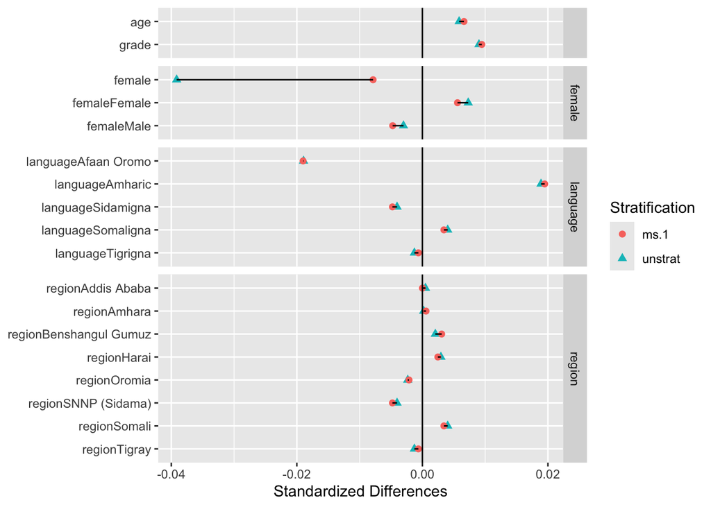

```r
matching_data$pscore <- glm(treatment ~ grade + female + age + language + region,
                            family = binomial, data = matching_data)$fitted.values

# ggplot(matching_data, aes(x = pscore, fill = factor(treatment))) +
#   geom_histogram(aes(y = after_stat(density)),
#                  alpha = 0.5, position = "identity", bins = 30) +
#   scale_fill_manual(values = c("blue", "red"),
#                     name = "Group",
#                     labels = c("Control", "Treatment")) +
#   labs(
#     title = "Distribution of Propensity Score by Treatment Group",
#     x = "Propensity Score",
#     y = "Count"
#   ) +
#   theme_minimal(base_size = 14)

options("optmatch_max_problem_size" = Inf)
match <- match_on(treatment ~ grade + female + age + language + region, data = matching_data)
ms <- pairmatch(match, data = matching_data)

# plot the covariate differences before and after matching
plot(xBalance(treatment ~ grade + female + age + language + region - 1,
              strata = list(unstrat = NULL, ms.1 = ~ms), data = matching_data), ggplot = TRUE)
```

```r
matching_data <- matching_data %>% mutate(pair_id = ms)
paste0("Proportion of matched units = ", mean(is.na(matching_data$pair_id)))
```

[output not shown]

```r
# pair_ps <- matching_data %>%
#   mutate(pair_id = ms) %>%
#   filter(!is.na(pair_id)) %>%
#   group_by(pair_id) %>%
#   summarise(
#     treat_ps = pscore[treatment == 1],
#     control_ps = pscore[treatment == 0],
#     abs_diff = abs(treat_ps - control_ps)
#   )
#
# # Compute average and maximum absolute difference
# avg_abs_diff_before <- mean(pair_ps$abs_diff, na.rm = TRUE)
# max_abs_diff_before <- max(pair_ps$abs_diff, na.rm = TRUE)
#
# cat("Average absolute PS difference =", round(avg_abs_diff_before, 4), "\n")
# cat("Maximum absolute PS difference =", round(max_abs_diff_before, 4), "\n")
#
# match_caliper <- addcaliper(match, z = matching_data$treatment, p = matching_data$pscore,
#                             caliper = 0.1 * sd(matching_data$pscore, na.rm = TRUE))
# ms_cal <- pairmatch(match_caliper, data = matching_data)
#
# # plot the covariate differences before and after matching
# plot(xBalance(treatment ~ grade + female + age + language + region - 1,
#               strata = list(unstrat = NULL, ms.1 = ~ms_cal), data = matching_data), ggplot = TRUE)
#
# # compute new pairwise PS differences after caliper matching
# pair_ps_cal <- matching_data %>%
#   mutate(pair_id = ms_cal) %>%
#   filter(!is.na(pair_id)) %>%
#   group_by(pair_id) %>%
#   summarise(
#     treat_ps = pscore[treatment == 1],
#     control_ps = pscore[treatment == 0],
#     abs_diff = abs(treat_ps - control_ps)
#   )
#
# # Average and maximum differences
# avg_abs_diff_after <- mean(pair_ps_cal$abs_diff, na.rm = TRUE)
# max_abs_diff_after <- max(pair_ps_cal$abs_diff, na.rm = TRUE)
#
# cat("Average absolute PS difference after caliper =", round(avg_abs_diff_after, 4), "\n")
# cat("Maximum absolute PS difference after caliper =", round(max_abs_diff_after, 4), "\n")

matched_data <- matching_data %>% filter(!is.na(pair_id))

# get the difference in y for each pairing
diff_vec <- c()
for (pair in unique(matched_data$pair_id)) {
  treatment_y <- matched_data[(matched_data$pair_id == pair) & (matched_data$treatment == 1), 'read_comp_score']
  control_y <- matched_data[(matched_data$pair_id == pair) & (matched_data$treatment == 0), 'read_comp_score']
  diff_vec <- c(diff_vec, treatment_y - control_y)
}
tau_hat <- mean(diff_vec)

# Fisher randomization test
set.seed(42)
B <- 1000
sampled_tau_hats <- c()
for (b in 1:B) {
  # randomly change treatment/control for some matched pairs
  random_signs <- sample(c(-1, +1), size = length(diff_vec), replace = TRUE)
  diff_vec_resamp <- diff_vec * random_signs
  sampled_tau_hats <- c(sampled_tau_hats, mean(diff_vec_resamp))
}

p_value <- mean(abs(sampled_tau_hats) >= abs(tau_hat))
cat("p-value =", p_value)
```

```
## p-value = 0
```

```r
tau_hat
```

```
## [1] 0.1944923
```